# Test on the first zip

```r
library(readr)
library(ggplot2)
library(tidyr)
```

## wea file

```r
# .wea file
preview_lines <- readLines("USA_CA_Fairfield-San.Francisco.Bay.Reserve.998011_TMYx.2007-2021/USA_CA_Fairfield-San.Francisco.Bay.Reserve.998011_TMYx.2007-2021.wea", n = 100)
#cat(preview_lines, sep = "\n")
wea_data <- read.table("USA_CA_Fairfield-San.Francisco.Bay.Reserve.998011_TMYx.2007-2021/USA_CA_Fairfield-San.Francisco.Bay.Reserve.998011_TMYx.2007-2021.wea", skip = 6, sep = " ", header = FALSE)
colnames(wea_data) <- c("Month", "Day", "Hour", "Global_Horizontal_Irradiance", "Direct_Normal_Irradiance")
head(wea_data)
```

```
##   Month Day Hour Global_Horizontal_Irradiance Direct_Normal_Irradiance
## 1     1   1    1                            0                        0
## 2     1   1    2                            0                        0
## 3     1   1    3                            0                        0
## 4     1   1    4                            0                        0
## 5     1   1    5                            0                        0
## 6     1   1    6                            0                        0
```

## Pvsyst file

```r
#.pvsyst file
getwd()
```

```
## [1] "/Users/delphia/Desktop/DAVIS/STA 141B/Homework 1"
```

```r
pvsline <- readLines("USA_CA_Fairfield-San.Francisco.Bay.Reserve.998011_TMYx.2007-2021/USA_CA_Fairfield-San.Francisco.Bay.Reserve.998011_TMYx.2007-2021.pvsyst", n = 50)
pvsdata <- read.table("USA_CA_Fairfield-San.Francisco.Bay.Reserve.998011_TMYx.2007-2021/USA_CA_Fairfield-San.Francisco.Bay.Reserve.998011_TMYx.2007-2021.pvsyst", skip = 14, sep = ",", col.names = c("Year", "Month", "Day", "Hour", "Minute", "GHI", "DHI", "DNI", "Tamb", "WindVel", "WindDir"))
head(pvsdata)
```

```
##   Year Month Day Hour Minute GHI DHI DNI Tamb WindVel WindDir
## 1 2059     1   1    1     30   0   0   0    5       4      90
## 2 2059     1   1    2     30   0   0   0    4       4      40
## 3 2059     1   1    3     30   0   0   0    3       5      70
## 4 2059     1   1    4     30   0   0   0    1       2      40
## 5 2059     1   1    5     30   0   0   0    1       3      80
## 6 2059     1   1    6     30   0   0   0    1       3      70
```

## Stat file

First, I will manually read each table and store it as a data-frame. Then, I will look for shared patterns among them and create functions to deconstruct the mechanics. Along with this, I will include a verification step to each monthly data set, which will involve manual reading tests to ensure the accuracy of the extracted data.

- Read the stat file as character vector using read_lines, and by specifying the encoding type, we can resolve the encoding issues.

```r
sf_statlines <- read_lines("USA_CA_Fairfield-San.Francisco.Bay.Reserve.998011_TMYx.2007-2021/USA_CA_Fairfield-San.Francisco.Bay.Reserve.998011_TMYx.2007-2021.stat", locale = locale(encoding = "ISO-8859-1"))
```

### Basic Functions Built-up

```r
# Function

# Transpose a datafram
transpose_dataframe <- function(data) {
  row_names <- data$X
  data$X <- NULL
  transposed_data <- t(data)
  transposed_data <- as.data.frame(transposed_data)
  colnames(transposed_data) <- row_names
  rownames(transposed_data) <- colnames(data)
  return(transposed_data)
}


# Convert the column Day:Hour into time variables
my_convert_to_time <- function(tdata){
  dayhour_col_vector <- grep("Day:Hour", names(tdata))
  if(length(dayhour_col_vector) == 0){
    warning("Day:Hour not found")
    return(tdata)
  }
  for (i in dayhour_col_vector) {
    for (j in 1:nrow(tdata)) {
      tdata[j,i]<-paste0("2023-", j,"-",substr(tdata[j,i],1,2), " ", substr(tdata[j,i],4,5), ":00:00")
    #print(as.POSIXct(tdata[j,i], format="%Y-%m-%d %H:%M:%S"))
    }
  }
  tdata[,dayhour_col_vector] <- lapply(tdata[,dayhour_col_vector], as.POSIXct, format="%Y-%m-%d %H:%M:%S")
  return(tdata)
}

# Read the char vactor as df
read_stat <- function(title, statlines){
  starts = grep(title, statlines)
  # grepl gives a boolean vector showing the seaching result, and we negate that result to
  # subset the sf_statlines
  ends = grep(" - ", statlines[(starts[1]+1) : length(statlines)], fixed = TRUE)
  temp <- statlines[(starts[1]+1) : (starts[1]+ends[1]-1)]
  temp <- temp[temp != ""]
  # use gsub with regular expression to rule out NAs in the first and last column
  # ^ means at the beginning, + means that the pattern might appear one or more times,
  # $ means is the end indicator, \\s and \\t represents space and tab respectively
  # gsub traverse the element in char vector, and see if the beggining and the end of an
  # element   is matching to the regular expression
  temp <- gsub("^(\\s\\t)+|(\\t)+$", "", temp)
  data <- read.table(text = temp, sep = '\t', header = TRUE)
  return(data)
}



# convert only char elements into numeric(double) for a df
df_to_numeric <- function(data){
  char_cols <- sapply(data, is.character)
  data[char_cols] <- lapply(data[char_cols], as.numeric)
  return(data)
}

# for hourly df: convert the first column to the row's name
first_row_to_colnames <- function(data){
  rownames(data) <- data$X
  data <- data[, -1]
  return(data)
}

# Turn hourly data into more a tidy data with 3 cols
hourly_3_cols <- function(data){
  data <- head(data, nrow(data) - 2) # remove max and min
  col_names <- colnames(data)
  row_names <- rownames(data)
  vec <- unlist(data)
  new_df <- data.frame(col = vec)
 # new_df <- cbind(new_df,row_names)
  new_df <- cbind(new_df,c(0:23))
  col_names <- rep(c(1:12), each = 12)
  new_df <- cbind(new_df,col_names)
  rownames(new_df) <- NULL
  return(new_df)
}

plot_hourly_df <- function(combined_df){
  var_names <- c("Dry Bulb temperatures", "Dew Point temperatures",
               "Relative Humidity", "Direct Normal Solar Radiation",
               "Wind Speed")
# Create heat maps along each calname with repect to month and hour
  for (name in var_names) {
    p <- ggplot(combined_df,
        aes(x = Hour, y = Month, fill = combined_df[,name])) +
    geom_tile() +
    scale_fill_gradient(low = "white", high = "red") +
    labs(x = "Hour", y = "Month", fill = name) +
    ggtitle(name)
    print(p)
  }
}
```

- Monthly Statistics for Dry Bulb temperatures

  ```r
  sf_statlines <- read_lines("USA_CA_Fairfield-San.Francisco.Bay.Reserve.998011_TMYx.2007-2021/USA_CA_Fairfield-San.Francisco.Bay.Reserve.998011_TMYx.2007-2021.stat", locale = locale(encoding = "ISO-8859-1"))
  data <- read_stat("Monthly Statistics for Dry Bulb temperatures",sf_statlines)
  tdata <- transpose_dataframe(data)
  tdata <- my_convert_to_time(tdata)
  tdata <- df_to_numeric(tdata)
  head(tdata)
  ```

  ```
  ##     Maximum             Day:Hour Minimum             Day:Hour Daily Avg
  ## Jan     24.4 2023-01-31 16:00:00     -0.8 2023-01-02 07:00:00       9.4
  ## Feb     24.7 2023-02-23 17:00:00      0.9 2023-02-27 07:00:00      10.9
  ## Mar     24.1 2023-03-13 18:00:00      2.6 2023-03-07 06:00:00      13.0
  ## Apr     31.4 2023-04-22 18:00:00      3.1 2023-04-06 07:00:00      14.0
  ## May     33.4 2023-05-21 16:00:00      6.8 2023-05-13 06:00:00      17.3
  ## Jun     37.8 2023-06-08 17:00:00     11.6 2023-06-19 06:00:00      19.8
  ##     Daily Range DayTime Max DayTime Min DayTime Avg NightTime Max NightTime Min
  ## Jan         9.5        24.4        -0.8        10.6          17.8          -0.3
  ## Feb        10.8        24.7         0.9        12.3          21.0           1.4
  ## Mar        11.3        24.1         3.1        14.7          23.1           2.6
  ## Apr        10.5        31.4         3.1        15.8          30.3           3.3
  ## May        13.3        33.4         7.4        20.6          28.3           6.8
  ## Jun        13.6        37.8        12.7        22.5          34.6          11.6
  ##     NightTime Avg
  ## Jan           8.2
  ## Feb           9.4
  ## Mar          11.3
  ## Apr          12.1
  ## May          14.0
  ## Jun          17.1
  ```

  ```r
  #starts = grep("Monthly Statistics for Dry Bulb temperatures", sf_statlines)
  # grepl gives a boolean vector showing the seaching result, and we negate that result to
  # subset the sf_statlines
  #ends = grep(" - ", sf_statlines[(starts[1]+1) : length(sf_statlines)], fixed = TRUE)
  #temp <- sf_statlines[(starts[1]+1) : (starts[1]+ends[1]-1)]
  #temp <- temp[temp != ""]
  # use gsub with regular expression to rule out NAs in the first and last column
  # ^ means at the beginning, + means that the pattern might appear one or more times,
  # $ means is the end indicator, \\s and \\t represents space and tab respectively
  # gsub traverse the element in char vector, and see if the beggining and the end of a element is matching to the regular expression
  #temp <- gsub("^(\\s\\t)+|(\\t)+$", "", temp)
  #data <- read.table(text = temp, sep = '\t', header = TRUE)
  ```

  - Verification: Maximum Dry Bulb temperature of 37.8C on Jun 8” and Minimum Dry Bulb temperature of -0.8C on Jan 2”
  - **According to the extracted data, they are consistent.**

```r
print(tdata[which(tdata$`Maximum ` == max(tdata$`Maximum `))[1],])
```

```
##     Maximum             Day:Hour Minimum             Day:Hour Daily Avg
## Jun     37.8 2023-06-08 17:00:00     11.6 2023-06-19 06:00:00      19.8
##     Daily Range DayTime Max DayTime Min DayTime Avg NightTime Max NightTime Min
## Jun        13.6        37.8        12.7        22.5          34.6          11.6
##     NightTime Avg
## Jun          17.1
```

```r
print(tdata[which(tdata$`Minimum ` == min(tdata$`Minimum `))[1],])
```

```
##     Maximum             Day:Hour Minimum             Day:Hour Daily Avg
## Jan     24.4 2023-01-31 16:00:00     -0.8 2023-01-02 07:00:00       9.4
##     Daily Range DayTime Max DayTime Min DayTime Avg NightTime Max NightTime Min
## Jan         9.5        24.4        -0.8        10.6          17.8          -0.3
##     NightTime Avg
## Jan           8.2
```

- Monthly Statistics for Dew Point temperatures

  ```r
  data <- read_stat("Monthly Statistics for Dew Point temperatures",sf_statlines)
  tdata <- transpose_dataframe(data)
  tdata <- my_convert_to_time(tdata)
  tdata <- df_to_numeric(tdata)
  head(tdata)
  ```

  ```
  ##     Maximum             Day:Hour Minimum             Day:Hour Daily Avg
  ## Jan     12.3 2023-01-18 18:00:00     -6.5 2023-01-31 12:00:00       6.6
  ## Feb     11.6 2023-02-10 15:00:00    -10.5 2023-02-23 12:00:00       4.2
  ## Mar     12.6 2023-03-14 15:00:00    -10.9 2023-03-22 16:00:00       6.9
  ## Apr     17.9 2023-04-22 17:00:00     -5.7 2023-04-10 14:00:00       8.0
  ## May     18.1 2023-05-03 09:00:00      2.7 2023-05-18 16:00:00      10.8
  ## Jun     17.2 2023-06-10 14:00:00      5.9 2023-06-18 18:00:00      12.2
  ```

  - Verification: Maximum Dew Point temperature of 18.3C on Aug 15” and Minimum Dew Point temperature of -11.2C on Dec 31”

    **According to the extracted data, they are consistent.**

  ```r
  print(tdata[which(tdata$`Maximum ` == max(tdata$`Maximum `))[1],])
  ```

  ```
  ##     Maximum             Day:Hour Minimum             Day:Hour Daily Avg
  ## Aug     18.3 2023-08-15 20:00:00        8 2023-08-21 18:00:00      12.8
  ```

  ```r
  print(tdata[which(tdata$`Minimum ` == min(tdata$`Minimum `))[1],])
  ```

  ```
  ##     Maximum             Day:Hour Minimum    Day:Hour Daily Avg
  ## Dec     12.3 2023-12-24 16:00:00    -11.2 2024-01-01       4.6
  ```

- Average Hourly Statistics for Dry Bulb temperatures

  ```r
  data <- read_stat("Average Hourly Statistics for Dry Bulb temperatures",sf_statlines)
  data <- first_row_to_colnames(data)
  data <- hourly_3_cols(data)
  head(data)
  ```

  ```
  ##   col c(0:23) col_names
  ## 1 7.6       0         1
  ## 2 7.3       1         1
  ## 3 6.9       2         1
  ## 4 6.9       3         1
  ## 5 6.7       4         1
  ## 6 6.4       5         1
  ```

  ```r
  #dayhour_col_vector <- grep("Day:Hour", names(data))
  #dayhour_col_vector
  ```

- Average Hourly Statistics for Dew Point temperatures

  ```r
  data <- read_stat("Average Hourly Statistics for Dew Point temperatures",sf_statlines)
  data <- first_row_to_colnames(data)
  data <- hourly_3_cols(data)
  head(data)
  ```

  ```
  ##   col c(0:23) col_names
  ## 1 5.8       0         1
  ## 2 5.8       1         1
  ## 3 5.8       2         1
  ## 4 5.7       3         1
  ## 5 5.5       4         1
  ## 6 5.2       5         1
  ```

- Average Hourly Relative Humidity

  ```r
  data <- read_stat("Average Hourly Relative Humidity",sf_statlines)
  data
  ```

  ```
  ##              X Jan Feb Mar Apr May Jun Jul Aug Sep Oct Nov Dec
  ## 1   0:01- 1:00  90  79  80  82  84  79  80  83  83  81  89  85
  ## 2   1:01- 2:00  92  81  82  83  86  81  82  85  84  82  89  85
  ## 3   2:01- 3:00  93  82  84  83  87  83  84  87  86  82  89  87
  ## 4   3:01- 4:00  93  84  85  84  89  84  85  88  88  84  91  87
  ## 5   4:01- 5:00  93  85  86  84  89  86  86  88  88  85  91  88
  ## 6   5:01- 6:00  93  85  86  85  90  86  86  89  89  85  92  87
  ## 7   6:01- 7:00  94  83  87  86  87  85  85  88  90  86  93  87
  ## 8   7:01- 8:00  94  84  87  83  78  79  79  79  88  88  93  88
  ## 9   8:01- 9:00  93  81  84  76  69  74  72  75  82  85  92  87
  ## 10  9:01-10:00  92  75  73  70  61  67  65  69  75  76  87  84
  ## 11 10:01-11:00  89  65  65  64  56  60  58  64  65  66  80  76
  ## 12 11:01-12:00  84  58  58  59  52  54  50  57  57  60  72  69
  ## 13 12:01-13:00  78  51  53  53  49  49  45  52  51  55  66  64
  ## 14 13:01-14:00  73  48  50  50  48  46  42  42  45  53  63  59
  ## 15 14:01-15:00  69  46  48  47  48  43  40  42  42  50  60  57
  ## 16 15:01-16:00  67  45  48  48  49  42  40  41  42  50  59  56
  ## 17 16:01-17:00  66  45  48  49  50  43  41  43  45  51  60  59
  ## 18 17:01-18:00  71  49  49  53  53  45  44  46  51  56  66  68
  ## 19 18:01-19:00  76  57  55  59  60  48  48  52  59  64  72  74
  ## 20 19:01-20:00  82  65  64  68  69  54  56  66  68  69  76  77
  ## 21 20:01-21:00  86  69  69  75  74  63  64  73  71  72  81  79
  ## 22 21:01-22:00  89  73  73  77  77  68  70  77  75  76  84  81
  ## 23 22:01-23:00  91  75  76  80  80  73  74  81  77  79  87  81
  ## 24 23:01-24:00  91  77  78  82  83  77  77  82  80  81  88  82
  ## 25  Max Hour     7   5   7   7   6   6   5   6   7   8   7   5
  ## 26  Min Hour    17  17  16  15  14  16  15  16  16  16  16  16
  ```

- Monthly Wind Direction {Interval 11.25 deg from displayed deg)

  ```r
  data <- read_stat("Monthly Wind Direction",sf_statlines)
  tdata <- transpose_dataframe(data)
  tdata <- df_to_numeric(tdata)
  tdata
  ```

  ```
  ##     N (0)       ENE (22.5)  NE (45)     ENE (67.5)  E (90)      ESE (112.5)
  ## Jan           5           5           6           9          21          11
  ## Feb           5           6           4          11           5           2
  ## Mar           4           1           2           2           5           3
  ## Apr           1           0           1           2           2           1
  ## May           1           1           0           1           1           0
  ## Jun           0           0           0           0           0           0
  ## Jul           0           0           1           0           0           0
  ## Aug           0           0           0           0           0           0
  ## Sep           1           0           0           1           0           0
  ## Oct           4           3           4           5           3           1
  ## Nov           5           4           4           6          15           4
  ## Dec           7           8           7          12          17           3
  ##     SE (135)    SSE (157.5) S (180)     SSW (202.5) SW (225)    WSW (247.5)
  ## Jan           9           6           4           3           5           3
  ## Feb           3           3           3           4           6           9
  ## Mar           3           2           2           4           6           7
  ## Apr           2           2           4           4           5          11
  ## May           0           1           2           1           3           3
  ## Jun           0           0           0           0           1           5
  ## Jul           0           0           0           0           4           2
  ## Aug           0           0           0           0           3           4
  ## Sep           0           0           0           1           1           3
  ## Oct           2           2           3           5          10          11
  ## Nov           4           4           9           5           6           7
  ## Dec           3           5           5           4           5           4
  ##     W (270)     WNW (292.5) NW (315)    NNW (337.5)
  ## Jan           4           3           3           3
  ## Feb          21           7           7           4
  ## Mar          24          25           6           3
  ## Apr          51           8           3           1
  ## May          45          34           5           2
  ## Jun          62          30           1           0
  ## Jul          58          33           1           0
  ## Aug          52          40           1           0
  ## Sep          44          42           4           2
  ## Oct          35           6           3           3
  ## Nov          12           9           4           2
  ## Dec           6           5           3           4
  ```

- Average Hourly Statistics for Direct Normal Solar Radiation

  ```r
  #Max Hour is 13, which indicates that the highest average solar radiation occurs between 13:01 and 14:00 (1:01 PM and 2:00 PM) in that month.
  data <- read_stat("Average Hourly Statistics for Direct Normal Solar Radiation",sf_statlines)
  data
  ```

  ```
  ##              X Jan Feb Mar   Apr   May   Jun Jul Aug Sep Oct Nov Dec
  ## 1   0:01- 1:00   0   0   0     0     0     0   0   0   0   0   0   0
  ## 2   1:01- 2:00   0   0   0     0     0     0   0   0   0   0   0   0
  ## 3   2:01- 3:00   0   0   0     0     0     0   0   0   0   0   0   0
  ## 4   3:01- 4:00   0   0   0     0     0     0   0   0   0   0   0   0
  ## 5   4:01- 5:00   0   0   0     0     0    65   0   0   0   0   0   0
  ## 6   5:01- 6:00   0   0   0   137   357   365 322 170  71   0   0   0
  ## 7   6:01- 7:00   0  30 223   411   523   526 478 431 413 209  61   0
  ## 8   7:01- 8:00 137 315 410   546   657   655 626 592 579 435 289 144
  ## 9   8:01- 9:00 327 474 533   634   758   746 743 727 724 554 396 334
  ## 10  9:01-10:00 404 568 611   688   787   793 815 832 811 655 498 416
  ## 11 10:01-11:00 496 641 646   709   782   799 847 885 835 719 556 474
  ## 12 11:01-12:00 603 691 669   707   785   797 869 899 845 745 585 517
  ## 13 12:01-13:00 653 685 661   692   777   792 877 894 852 750 585 511
  ## 14 13:01-14:00 637 656 633   678   761   771 875 878 827 719 546 479
  ## 15 14:01-15:00 570 597 587   643   735   740 851 849 776 646 460 402
  ## 16 15:01-16:00 446 484 506   575   698   700 801 785 693 503 293 226
  ## 17 16:01-17:00 131 260 390   463   613   628 715 664 545 216  32   0
  ## 18 17:01-18:00   0   0 136   249   451   488 557 437 186   0   0   0
  ## 19 18:01-19:00   0   0   0     0   133   197 228  90   0   0   0   0
  ## 20 19:01-20:00   0   0   0     0     0     0   0   0   0   0   0   0
  ## 21 20:01-21:00   0   0   0     0     0     0   0   0   0   0   0   0
  ## 22 21:01-22:00   0   0   0     0     0     0   0   0   0   0   0   0
  ## 23 22:01-23:00   0   0   0     0     0     0   0   0   0   0   0   0
  ## 24 23:01-24:00   0   0   0     0     0     0   0   0   0   0   0   0
  ## 25   Max Hour*  13  12  12   11*   10*   11*  13  12  13  13  12  12
  ## 26  Min Hour     1   1   1    1     1     1    1   1   1   1   1   1
  ```

- Monthly Statistics for Wind Speed

  ```r
  data <- read_stat("Monthly Statistics for Wind Speed",sf_statlines)
  tdata <- transpose_dataframe(data)
  tdata <- my_convert_to_time(tdata)
  tdata <- df_to_numeric(tdata)
  tdata
  ```

  ```
  ##     Maximum            Day:Hour  Minimum            Day:Hour  Daily Avg
  ## Jan      6.7 2023-01-31 13:00:00      0.0 2023-01-02 09:00:00       1.8
  ## Feb      9.3 2023-02-15 12:00:00      0.0 2023-02-01 22:00:00       2.7
  ## Mar      9.8 2023-03-22 11:00:00      0.0 2023-03-01 20:00:00       3.1
  ## Apr     10.3 2023-04-01 15:00:00      0.0 2023-04-08 00:00:00       3.9
  ## May      9.8 2023-05-12 16:00:00      0.0 2023-05-02 20:00:00       4.3
  ## Jun     10.3 2023-06-18 17:00:00      0.5 2023-06-08 21:00:00       5.1
  ## Jul     10.3 2023-07-06 16:00:00      1.5 2023-07-06 23:00:00       6.0
  ## Aug      9.3 2023-08-21 09:00:00      1.0 2023-08-13 12:00:00       5.4
  ## Sep      8.8 2023-09-08 09:00:00      0.5 2023-09-11 10:00:00       4.4
  ## Oct      7.2 2023-10-15 18:00:00      0.0 2023-10-03 21:00:00       2.6
  ## Nov      7.2 2023-11-08 15:00:00      0.0 2023-11-01 23:00:00       2.2
  ## Dec     12.4 2023-12-31 07:00:00      0.0 2023-12-02 07:00:00       2.5
  ```

  - Verification: Maximum Wind Speed of 12.4 m/s on Dec 31” and Minimum Wind Speed of 0.0 m/s on Jan 2”

    **According to the extracted data, they are consistent.**

  ```r
  print(tdata[which(tdata$`Maximum ` == max(tdata$`Maximum `))[1],])
  ```

  ```
  ##     Maximum            Day:Hour  Minimum            Day:Hour  Daily Avg
  ## Dec     12.4 2023-12-31 07:00:00        0 2023-12-02 07:00:00       2.5
  ```

  ```r
  print(tdata[which(tdata$`Minimum ` == min(tdata$`Minimum `))[1],])
  ```

  ```
  ##     Maximum            Day:Hour  Minimum            Day:Hour  Daily Avg
  ## Jan      6.7 2023-01-31 13:00:00        0 2023-01-02 09:00:00       1.8
  ```

- Average Hourly Statistics for Wind Speed

  ```r
  data <- read_stat("Average Hourly Statistics for Wind Speed",sf_statlines)
  data
  ```

  ```
  ##              X  Jan  Feb  Mar  Apr  May  Jun  Jul  Aug  Sep  Oct  Nov  Dec
  ## 1   0:01- 1:00  1.3  2.1  2.5  3.6  4.0  5.0  5.8  4.7  4.0  2.1  1.5  2.1
  ## 2   1:01- 2:00  1.7  2.1  2.5  3.4  3.9  4.7  5.9  4.8  4.4  2.2  1.9  1.7
  ## 3   2:01- 3:00  1.8  2.3  2.2  3.3  3.9  4.7  5.6  4.7  4.4  2.1  1.6  1.6
  ## 4   3:01- 4:00  1.9  2.1  2.3  3.3  3.6  4.4  5.6  5.1  4.1  2.0  1.6  1.7
  ## 5   4:01- 5:00  1.7  2.1  2.3  2.9  3.6  4.0  5.9  4.9  4.0  1.8  1.6  1.6
  ## 6   5:01- 6:00  1.7  2.0  2.3  2.8  3.2  4.1  5.1  4.5  3.8  1.8  1.4  2.0
  ## 7   6:01- 7:00  1.7  2.4  2.1  2.9  3.2  4.3  5.6  4.7  3.8  1.4  1.5  1.9
  ## 8   7:01- 8:00  1.5  2.1  2.0  2.7  3.6  5.0  5.7  5.2  4.0  1.6  1.4  1.9
  ## 9   8:01- 9:00  1.8  2.0  2.1  3.5  3.8  5.2  5.8  5.9  4.5  1.9  1.7  1.8
  ## 10  9:01-10:00  1.9  2.7  2.9  3.9  3.9  5.2  5.8  5.6  4.4  2.3  2.2  2.4
  ## 11 10:01-11:00  2.0  3.2  3.7  4.0  4.3  5.1  5.8  5.6  4.4  3.1  2.6  3.1
  ## 12 11:01-12:00  2.3  3.9  3.9  4.0  4.3  5.2  5.8  5.3  4.2  3.5  3.0  3.4
  ## 13 12:01-13:00  2.5  4.1  4.1  4.0  4.3  5.1  6.0  5.3  4.1  3.4  3.0  3.6
  ## 14 13:01-14:00  2.6  4.0  3.8  4.0  4.6  5.6  6.4  5.7  4.4  3.5  3.4  3.7
  ## 15 14:01-15:00  2.6  3.6  4.1  4.4  5.2  6.0  6.7  6.1  4.9  3.8  3.3  3.9
  ## 16 15:01-16:00  2.5  3.5  4.2  5.0  5.5  6.3  7.2  6.5  5.3  3.8  3.4  3.4
  ## 17 16:01-17:00  2.2  3.4  4.1  5.1  5.9  6.8  7.4  6.9  5.6  3.8  3.0  3.3
  ## 18 17:01-18:00  1.5  3.1  4.2  5.4  6.0  6.7  7.1  6.9  5.6  3.3  2.7  2.7
  ## 19 18:01-19:00  1.7  2.5  3.5  5.2  5.3  6.1  6.8  6.3  5.0  2.7  2.5  2.5
  ## 20 19:01-20:00  1.6  2.6  3.1  4.4  4.8  5.0  6.0  5.5  4.1  2.1  2.2  2.5
  ## 21 20:01-21:00  1.2  2.3  3.0  3.8  4.5  4.3  5.5  5.1  4.5  2.3  1.8  2.2
  ## 22 21:01-22:00  1.2  2.0  3.0  3.6  4.5  4.6  5.7  4.7  4.1  2.3  1.6  2.4
  ## 23 22:01-23:00  1.2  2.2  3.0  3.8  4.0  4.7  5.7  4.4  4.3  2.2  1.4  2.1
  ## 24 23:01-24:00  1.3  2.2  2.9  3.5  4.0  4.8  5.6  4.8  4.1  2.1  1.4  2.1
  ## 25  Max Hour   15.0 13.0 16.0 18.0 18.0 17.0 17.0 17.0 18.0 17.0 14.0 15.0
  ## 26  Min Hour   23.0  9.0  8.0  8.0  6.0  5.0  6.0 23.0  6.0  7.0  6.0  5.0
  ```

### Combine hourly data

After building up the functions and conducting a few tests, it’s time to integrate all of them into one with respect to the titles.

```r
data1 <- read_stat("Average Hourly Statistics for Dry Bulb temperatures",sf_statlines)
data1 <- first_row_to_colnames(data1)
data1 <- hourly_3_cols(data1)
head(data1)
```

```
##   col c(0:23) col_names
## 1 7.6       0         1
## 2 7.3       1         1
## 3 6.9       2         1
## 4 6.9       3         1
## 5 6.7       4         1
## 6 6.4       5         1
```

```r
data2 <- read_stat("Average Hourly Statistics for Dew Point temperatures",sf_statlines)
data2 <- first_row_to_colnames(data2)
data2 <- hourly_3_cols(data2)
head(data2)
```

```
##   col c(0:23) col_names
## 1 5.8       0         1
## 2 5.8       1         1
## 3 5.8       2         1
## 4 5.7       3         1
## 5 5.5       4         1
## 6 5.2       5         1
```

```r
data3 <- read_stat("Average Hourly Relative Humidity",sf_statlines)
data3 <- first_row_to_colnames(data3)
data3 <- hourly_3_cols(data3)
head(data3)
```

```
##   col c(0:23) col_names
## 1  90       0         1
## 2  92       1         1
## 3  93       2         1
## 4  93       3         1
## 5  93       4         1
## 6  93       5         1
```

```r
data4 <- read_stat("Average Hourly Statistics for Direct Normal Solar Radiation",sf_statlines)
data4 <- first_row_to_colnames(data4)
data4 <- hourly_3_cols(data4)
head(data4)
```

```
##   col c(0:23) col_names
## 1   0       0         1
## 2   0       1         1
## 3   0       2         1
## 4   0       3         1
## 5   0       4         1
## 6   0       5         1
```

```r
data5 <- read_stat("Average Hourly Statistics for Wind Speed",sf_statlines)
data5 <- first_row_to_colnames(data5)
data5 <- hourly_3_cols(data5)
head(data5)
```

```
##   col c(0:23) col_names
## 1 1.3       0         1
## 2 1.7       1         1
## 3 1.8       2         1
## 4 1.9       3         1
## 5 1.7       4         1
## 6 1.7       5         1
```

```r
time_df <- data1[,2:3]
combined_df <- cbind(time_df, data1[, 1],data2[, 1],data3[, 1],data4[, 1],data5[, 1])
colnames(combined_df) <- c("Hour", "Month" ,"Dry Bulb temperatures", "Dew Point temperatures", "Relative Humidity", "Direct Normal Solar Radiation", "Wind Speed")
combined_df <- df_to_numeric(combined_df)
head(combined_df)
```

```
##   Hour Month Dry Bulb temperatures Dew Point temperatures Relative Humidity
## 1    0     1                   7.6                    5.8                90
## 2    1     1                   7.3                    5.8                92
## 3    2     1                   6.9                    5.8                93
## 4    3     1                   6.9                    5.7                93
## 5    4     1                   6.7                    5.5                93
## 6    5     1                   6.4                    5.2                93
##   Direct Normal Solar Radiation Wind Speed
## 1                             0        1.3
## 2                             0        1.7
## 3                             0        1.8
## 4                             0        1.9
## 5                             0        1.7
## 6                             0        1.7
```

### Plotting Hourly Integrated Data

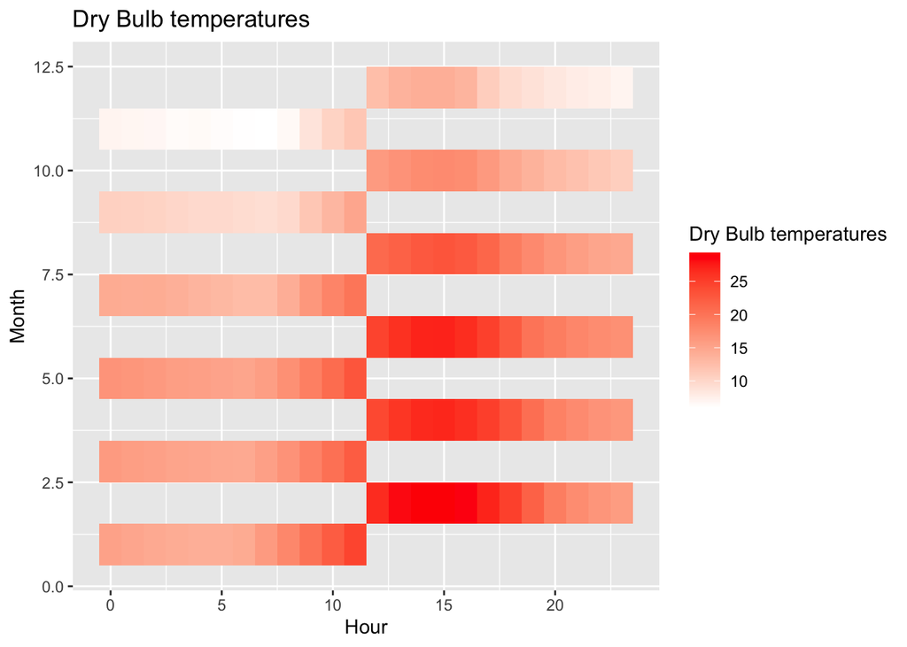

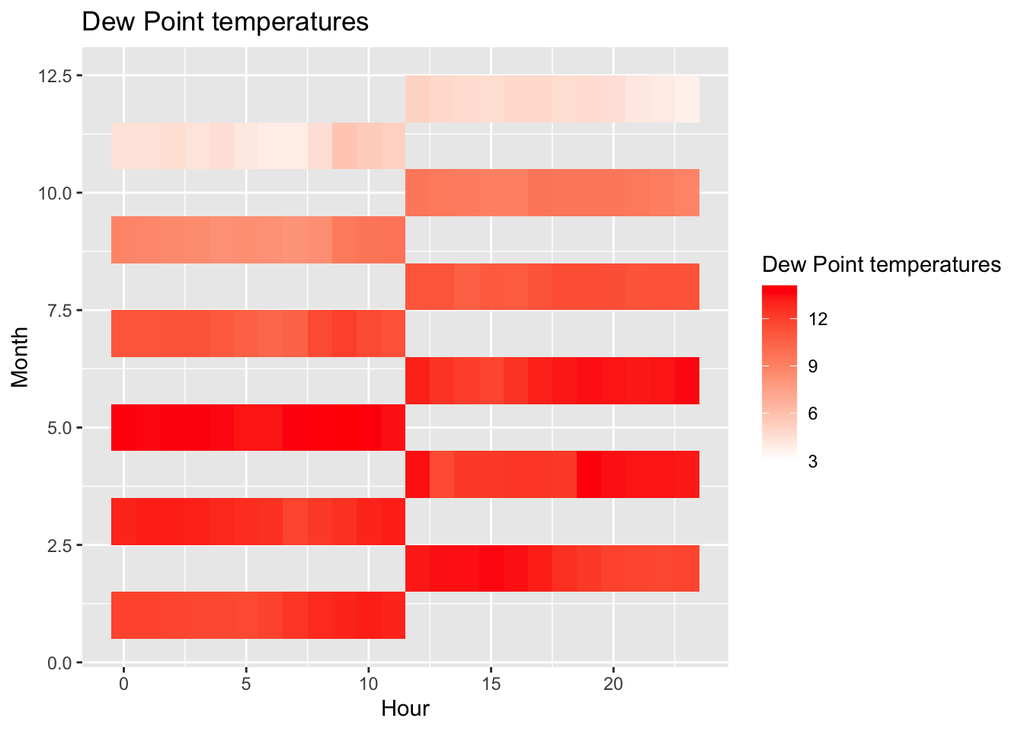

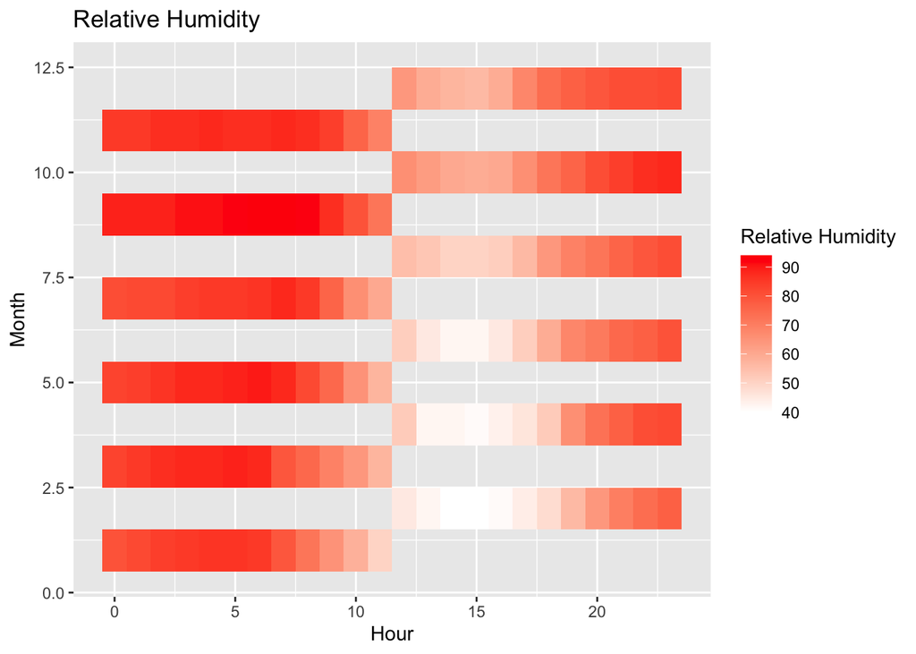

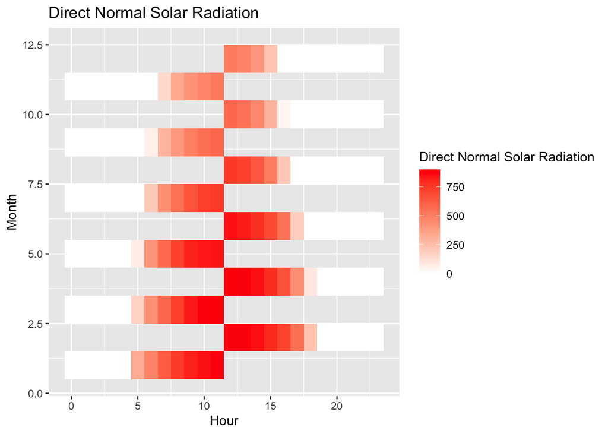

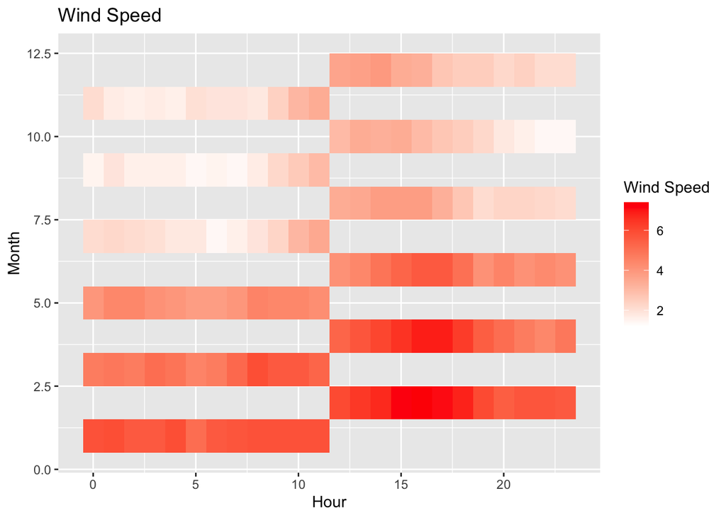

```r
plot_hourly_df(combined_df)
```

# Apply to all five zips

```r
library(readr)
library(ggplot2)
library(tidyr)
read_wea <- function(path){
#cat(preview_lines, sep = "\n")
  wea_data <- read.table(path, skip = 6, sep = " ", header = FALSE)
  colnames(wea_data) <- c("Month", "Day", "Hour", "Global_Horizontal_Irradiance", "Direct_Normal_Irradiance")
  return(wea_data)
}

read_pvsyst <- function(path){
  #cat(preview_lines, sep = "\n")
  pvsdata <- read.table(path, skip = 14, sep = ",", col.names = c("Year", "Month", "Day", "Hour", "Minute", "GHI", "DHI", "DNI", "Tamb", "WindVel", "WindDir"))
  return(pvsdata)
}

combine_hour <- function(data1, data2, data3, data4, data5){
  time_df <- data1[,2:3]
  combined_df <- cbind(time_df, data1[, 1],data2[, 1],data3[, 1],data4[, 1],data5[, 1])
  colnames(combined_df) <- c("Hour", "Month" ,"Dry Bulb temperatures", "Dew Point temperatures", "Relative Humidity", "Direct Normal Solar Radiation", "Wind Speed")
  combined_df <- df_to_numeric(combined_df)
  return(combined_df)
}



#Stat
# Function

# Transpose a datafram
transpose_dataframe <- function(data) {
  row_names <- data$X
  data$X <- NULL
  transposed_data <- t(data)
  transposed_data <- as.data.frame(transposed_data)
  colnames(transposed_data) <- row_names
  rownames(transposed_data) <- colnames(data)
  return(transposed_data)
}


# Convert the column Day:Hour into time variables
my_convert_to_time <- function(tdata){
  dayhour_col_vector <- grep("Day:Hour", names(tdata))
  if(length(dayhour_col_vector) == 0){
    warning("Day:Hour not found")
    return(tdata)
  }
  for (i in dayhour_col_vector) {
    for (j in 1:nrow(tdata)) {
      tdata[j,i]<-paste0("2023-", j,"-",substr(tdata[j,i],1,2), " ", substr(tdata[j,i],4,5), ":00:00")
    #print(as.POSIXct(tdata[j,i], format="%Y-%m-%d %H:%M:%S"))
    }
  }
  tdata[,dayhour_col_vector] <- lapply(tdata[,dayhour_col_vector], as.POSIXct, format="%Y-%m-%d %H:%M:%S")
  return(tdata)
}

# Read the char vactor as df
read_stat <- function(title, statlines){
  starts = grep(title, statlines)
  # grepl gives a boolean vector showing the seaching result, and we negate that result to
  # subset the sf_statlines
  ends = grep(" - ", statlines[(starts[1]+1) : length(statlines)], fixed = TRUE)
  temp <- statlines[(starts[1]+1) : (starts[1]+ends[1]-1)]
  temp <- temp[temp != ""]
  # use gsub with regular expression to rule out NAs in the first and last column
  # ^ means at the beginning, + means that the pattern might appear one or more times,
  # $ means is the end indicator, \\s and \\t represents space and tab respectively
  # gsub traverse the element in char vector, and see if the beggining and the end of an
  # element   is matching to the regular expression
  temp <- gsub("^(\\s\\t)+|(\\t)+$", "", temp)
  data <- read.table(text = temp, sep = '\t', header = TRUE)
  return(data)
}



# convert only char elements into numeric(double) for a df
df_to_numeric <- function(data){
  char_cols <- sapply(data, is.character)
  data[char_cols] <- lapply(data[char_cols], as.numeric)
  return(data)
}

# for hourly df: convert the first column to the row's name
first_row_to_colnames <- function(data){
  rownames(data) <- data$X
  data <- data[, -1]
  return(data)
}

# Turn hourly data into a more tidy data with 3 cols
hourly_3_cols <- function(data){
  data <- head(data, nrow(data) - 2) # remove max and min
  col_names <- colnames(data)
  row_names <- rownames(data)
  vec <- unlist(data)
  new_df <- data.frame(col = vec)
 # new_df <- cbind(new_df,row_names)
  new_df <- cbind(new_df,c(0:23))
  col_names <- rep(c(1:12), each = 12)
  new_df <- cbind(new_df,col_names)
  rownames(new_df) <- NULL
  return(new_df)
}

plot_hourly_df <- function(combined_df){
  var_names <- c("Dry Bulb temperatures", "Dew Point temperatures",
               "Relative Humidity", "Direct Normal Solar Radiation",
               "Wind Speed")
# Create heat maps along each calname with repect to month and hour
  for (name in var_names) {
    p <- ggplot(combined_df,
        aes(x = Hour, y = Month, fill = combined_df[,name])) +
    geom_tile() +
    scale_fill_gradient(low = "white", high = "red") +
    labs(x = "Hour", y = "Month", fill = name) +
    ggtitle(name)
    print(p)
  }
}
```

## San Francisco

### .wea file

```r
# .wea file
sf_path_wea <- "USA_CA_Fairfield-San.Francisco.Bay.Reserve.998011_TMYx.2007-2021/USA_CA_Fairfield-San.Francisco.Bay.Reserve.998011_TMYx.2007-2021.wea"
wea_data_sf <- read_wea(sf_path_wea)
head(wea_data_sf)
```

```
##   Month Day Hour Global_Horizontal_Irradiance Direct_Normal_Irradiance
## 1     1   1    1                            0                        0
## 2     1   1    2                            0                        0
## 3     1   1    3                            0                        0
## 4     1   1    4                            0                        0
## 5     1   1    5                            0                        0
## 6     1   1    6                            0                        0
```

### .pvsyst file

```r
sf_path_pvsyst <- "USA_CA_Fairfield-San.Francisco.Bay.Reserve.998011_TMYx.2007-2021/USA_CA_Fairfield-San.Francisco.Bay.Reserve.998011_TMYx.2007-2021.pvsyst"
sf_pvsyst_data <- read_pvsyst(sf_path_pvsyst)
head(sf_pvsyst_data)
```

```
##   Year Month Day Hour Minute GHI DHI DNI Tamb WindVel WindDir
## 1 2059     1   1    1     30   0   0   0    5       4      90
## 2 2059     1   1    2     30   0   0   0    4       4      40
## 3 2059     1   1    3     30   0   0   0    3       5      70
## 4 2059     1   1    4     30   0   0   0    1       2      40
## 5 2059     1   1    5     30   0   0   0    1       3      80
## 6 2059     1   1    6     30   0   0   0    1       3      70
```

### .stat file

```r
sf_statlines <- read_lines("USA_CA_Fairfield-San.Francisco.Bay.Reserve.998011_TMYx.2007-2021/USA_CA_Fairfield-San.Francisco.Bay.Reserve.998011_TMYx.2007-2021.stat", locale = locale(encoding = "ISO-8859-1"))
```

#### Monthly Statistics for Dry Bulb temperatures

```r
sf_stat_data_month_dry_bulb_temp <- read_stat("Monthly Statistics for Dry Bulb temperatures",sf_statlines)
sf_stat_data_month_dry_bulb_temp_t <- transpose_dataframe(sf_stat_data_month_dry_bulb_temp)
sf_stat_data_month_dry_bulb_temp_t <- my_convert_to_time(sf_stat_data_month_dry_bulb_temp_t)
sf_stat_data_month_dry_bulb_temp_t <- df_to_numeric(sf_stat_data_month_dry_bulb_temp_t)
head(sf_stat_data_month_dry_bulb_temp_t)
```

```
##     Maximum             Day:Hour Minimum             Day:Hour Daily Avg
## Jan     24.4 2023-01-31 16:00:00     -0.8 2023-01-02 07:00:00       9.4
## Feb     24.7 2023-02-23 17:00:00      0.9 2023-02-27 07:00:00      10.9
## Mar     24.1 2023-03-13 18:00:00      2.6 2023-03-07 06:00:00      13.0
## Apr     31.4 2023-04-22 18:00:00      3.1 2023-04-06 07:00:00      14.0
## May     33.4 2023-05-21 16:00:00      6.8 2023-05-13 06:00:00      17.3
## Jun     37.8 2023-06-08 17:00:00     11.6 2023-06-19 06:00:00      19.8
##     Daily Range DayTime Max DayTime Min DayTime Avg NightTime Max NightTime Min
## Jan         9.5        24.4        -0.8        10.6          17.8          -0.3
## Feb        10.8        24.7         0.9        12.3          21.0           1.4
## Mar        11.3        24.1         3.1        14.7          23.1           2.6
## Apr        10.5        31.4         3.1        15.8          30.3           3.3
## May        13.3        33.4         7.4        20.6          28.3           6.8
## Jun        13.6        37.8        12.7        22.5          34.6          11.6
##     NightTime Avg
## Jan           8.2
## Feb           9.4
## Mar          11.3
## Apr          12.1
## May          14.0
## Jun          17.1
```

#### Monthly Statistics for Dew Point temperatures

```r
sf_stat_data_month_dew_point_temp <- read_stat("Monthly Statistics for Dew Point temperatures",sf_statlines)
sf_stat_data_month_dew_point_temp_t <- transpose_dataframe(sf_stat_data_month_dew_point_temp)
sf_stat_data_month_dew_point_temp_t <- my_convert_to_time(sf_stat_data_month_dew_point_temp_t)
sf_stat_data_month_dew_point_temp_t <- df_to_numeric(sf_stat_data_month_dew_point_temp_t)
head(sf_stat_data_month_dew_point_temp_t)
```

```
##     Maximum             Day:Hour Minimum             Day:Hour Daily Avg
## Jan     12.3 2023-01-18 18:00:00     -6.5 2023-01-31 12:00:00       6.6
## Feb     11.6 2023-02-10 15:00:00    -10.5 2023-02-23 12:00:00       4.2
## Mar     12.6 2023-03-14 15:00:00    -10.9 2023-03-22 16:00:00       6.9
## Apr     17.9 2023-04-22 17:00:00     -5.7 2023-04-10 14:00:00       8.0
## May     18.1 2023-05-03 09:00:00      2.7 2023-05-18 16:00:00      10.8
## Jun     17.2 2023-06-10 14:00:00      5.9 2023-06-18 18:00:00      12.2
```

#### Average Hourly Statistics for Dry Bulb

```r
sf_stat_data_hour_dry_bulb_temp <- read_stat("Average Hourly Statistics for Dry Bulb temperatures",sf_statlines)
sf_stat_data_hour_dry_bulb_temp <- first_row_to_colnames(sf_stat_data_hour_dry_bulb_temp)
head(sf_stat_data_hour_dry_bulb_temp)
```

```
##             Jan Feb  Mar  Apr  May  Jun  Jul  Aug  Sep  Oct  Nov Dec
##  0:01- 1:00 7.6 8.7 10.5 11.4 13.0 15.6 15.3 16.0 16.7 14.4 10.6 7.1
##  1:01- 2:00 7.3 8.2 10.0 11.1 12.7 15.2 14.9 15.7 16.5 14.2 10.5 6.9
##  2:01- 3:00 6.9 8.0  9.8 10.9 12.3 14.9 14.5 15.4 16.1 14.3 10.3 6.8
##  3:01- 4:00 6.9 7.7  9.4 10.6 11.9 14.6 14.2 15.1 15.7 13.9 10.0 6.4
##  4:01- 5:00 6.7 7.4  9.0 10.3 11.8 14.3 14.0 14.9 15.5 13.4  9.7 6.5
##  5:01- 6:00 6.4 7.1  8.8  9.9 11.7 14.1 14.0 14.6 15.2 13.1  9.7 6.3
```

#### Average Hourly Statistics for Dew Point temperatures

```r
sf_stat_data_hour_dew_point_temp <- read_stat("Average Hourly Statistics for Dew Point temperatures",sf_statlines)
sf_stat_data_hour_dew_point_temp <- first_row_to_colnames(sf_stat_data_hour_dew_point_temp)
head(sf_stat_data_hour_dew_point_temp)
```

```
##             Jan Feb Mar Apr  May  Jun  Jul  Aug  Sep  Oct Nov Dec
##  0:01- 1:00 5.8 4.5 7.1 8.4 10.3 11.9 11.9 13.0 13.7 11.1 8.9 4.4
##  1:01- 2:00 5.8 4.8 7.0 8.2 10.3 12.0 11.9 13.2 13.6 11.1 8.8 4.4
##  2:01- 3:00 5.8 4.8 7.1 8.1 10.1 12.0 11.8 13.2 13.7 11.2 8.6 4.6
##  3:01- 4:00 5.7 4.8 7.0 7.9 10.1 12.0 11.7 13.1 13.7 11.2 8.5 4.3
##  4:01- 5:00 5.5 4.7 6.7 7.7 10.1 12.0 11.7 12.9 13.6 10.9 8.3 4.5
##  5:01- 6:00 5.2 4.5 6.6 7.5 10.0 11.9 11.6 12.7 13.4 10.6 8.4 4.1
```

#### Average Hourly Relative Humidity

```r
sf_stat_data_hour_relative_humid <- read_stat("Average Hourly Relative Humidity",sf_statlines)
sf_stat_data_hour_relative_humid <- first_row_to_colnames(sf_stat_data_hour_relative_humid)
head(sf_stat_data_hour_relative_humid)
```

```
##             Jan Feb Mar Apr May Jun Jul Aug Sep Oct Nov Dec
##  0:01- 1:00  90  79  80  82  84  79  80  83  83  81  89  85
##  1:01- 2:00  92  81  82  83  86  81  82  85  84  82  89  85
##  2:01- 3:00  93  82  84  83  87  83  84  87  86  82  89  87
##  3:01- 4:00  93  84  85  84  89  84  85  88  88  84  91  87
##  4:01- 5:00  93  85  86  84  89  86  86  88  88  85  91  88
##  5:01- 6:00  93  85  86  85  90  86  86  89  89  85  92  87
```

#### Monthly Wind Direction

```r
sf_stat_data_month_wind_direction <- read_stat("Monthly Wind Direction",sf_statlines)
sf_stat_data_month_wind_direction_t <- transpose_dataframe(sf_stat_data_month_wind_direction)
sf_stat_data_month_wind_direction_t <- df_to_numeric(sf_stat_data_month_wind_direction_t)
head(sf_stat_data_month_wind_direction_t)
```

```
##     N (0)       ENE (22.5)  NE (45)     ENE (67.5)  E (90)      ESE (112.5)
## Jan           5           5           6           9          21          11
## Feb           5           6           4          11           5           2
## Mar           4           1           2           2           5           3
## Apr           1           0           1           2           2           1
## May           1           1           0           1           1           0
## Jun           0           0           0           0           0           0
##     SE (135)    SSE (157.5) S (180)     SSW (202.5) SW (225)    WSW (247.5)
## Jan           9           6           4           3           5           3
## Feb           3           3           3           4           6           9
## Mar           3           2           2           4           6           7
## Apr           2           2           4           4           5          11
## May           0           1           2           1           3           3
## Jun           0           0           0           0           1           5
##     W (270)     WNW (292.5) NW (315)    NNW (337.5)
## Jan           4           3           3           3
## Feb          21           7           7           4
## Mar          24          25           6           3
## Apr          51           8           3           1
## May          45          34           5           2
## Jun          62          30           1           0
```

#### Average Hourly Statistics for Direct Normal Solar Radiation

```r
sf_stat_data_hour_dircect_NSR <- read_stat("Average Hourly Statistics for Direct Normal Solar Radiation",sf_statlines)
sf_stat_data_hour_dircect_NSR <- first_row_to_colnames(sf_stat_data_hour_dircect_NSR)
head(sf_stat_data_hour_dircect_NSR)
```

```
##             Jan Feb Mar   Apr   May   Jun Jul Aug Sep Oct Nov Dec
##  0:01- 1:00   0   0   0     0     0     0   0   0   0   0   0   0
##  1:01- 2:00   0   0   0     0     0     0   0   0   0   0   0   0
##  2:01- 3:00   0   0   0     0     0     0   0   0   0   0   0   0
##  3:01- 4:00   0   0   0     0     0     0   0   0   0   0   0   0
##  4:01- 5:00   0   0   0     0     0    65   0   0   0   0   0   0
##  5:01- 6:00   0   0   0   137   357   365 322 170  71   0   0   0
```

#### Monthly Statistics for Wind Speed

```r
sf_stat_data_month_wind_speed <- read_stat("Monthly Statistics for Wind Speed",sf_statlines)
sf_stat_data_month_wind_speed_t <- transpose_dataframe(sf_stat_data_month_wind_speed)
sf_stat_data_month_wind_speed_t <- my_convert_to_time(sf_stat_data_month_wind_speed_t)
sf_stat_data_month_wind_speed_t <- df_to_numeric(sf_stat_data_month_wind_speed_t)
head(sf_stat_data_month_wind_speed_t)
```

```
##     Maximum            Day:Hour  Minimum            Day:Hour  Daily Avg
## Jan      6.7 2023-01-31 13:00:00      0.0 2023-01-02 09:00:00       1.8
## Feb      9.3 2023-02-15 12:00:00      0.0 2023-02-01 22:00:00       2.7
## Mar      9.8 2023-03-22 11:00:00      0.0 2023-03-01 20:00:00       3.1
## Apr     10.3 2023-04-01 15:00:00      0.0 2023-04-08 00:00:00       3.9
## May      9.8 2023-05-12 16:00:00      0.0 2023-05-02 20:00:00       4.3
## Jun     10.3 2023-06-18 17:00:00      0.5 2023-06-08 21:00:00       5.1
```

```r
sf_stat_data_hour_wind_speed <- read_stat("Average Hourly Relative Humidity",sf_statlines)
sf_stat_data_hour_wind_speed <- first_row_to_colnames(sf_stat_data_hour_wind_speed)
head(sf_stat_data_hour_wind_speed)
```

```
##             Jan Feb Mar Apr May Jun Jul Aug Sep Oct Nov Dec
##  0:01- 1:00  90  79  80  82  84  79  80  83  83  81  89  85
##  1:01- 2:00  92  81  82  83  86  81  82  85  84  82  89  85
##  2:01- 3:00  93  82  84  83  87  83  84  87  86  82  89  87
##  3:01- 4:00  93  84  85  84  89  84  85  88  88  84  91  87
##  4:01- 5:00  93  85  86  84  89  86  86  88  88  85  91  88
##  5:01- 6:00  93  85  86  85  90  86  86  89  89  85  92  87
```

### Combine Hourly and Plot

```r
# Combine
sf_stat_data_hour_dry_bulb_temp_3_cols <- hourly_3_cols(sf_stat_data_hour_dry_bulb_temp)
head(sf_stat_data_hour_dry_bulb_temp_3_cols)
```

```
##   col c(0:23) col_names
## 1 7.6       0         1
## 2 7.3       1         1
## 3 6.9       2         1
## 4 6.9       3         1
## 5 6.7       4         1
## 6 6.4       5         1
```

```r
sf_stat_data_hour_dew_point_temp_3_cols <- hourly_3_cols(sf_stat_data_hour_dew_point_temp)
head(sf_stat_data_hour_dew_point_temp_3_cols)
```

```
##   col c(0:23) col_names
## 1 5.8       0         1
## 2 5.8       1         1
## 3 5.8       2         1
## 4 5.7       3         1
## 5 5.5       4         1
## 6 5.2       5         1
```

```r
sf_stat_data_hour_relative_humid_3_cols <- hourly_3_cols(sf_stat_data_hour_relative_humid)
head(sf_stat_data_hour_relative_humid_3_cols)
```

```
##   col c(0:23) col_names
## 1  90       0         1
## 2  92       1         1
## 3  93       2         1
## 4  93       3         1
## 5  93       4         1
## 6  93       5         1
```

```r
sf_stat_data_hour_dircect_NSR_3_cols <- hourly_3_cols(sf_stat_data_hour_relative_humid)
head(sf_stat_data_hour_dircect_NSR_3_cols)
```

```
##   col c(0:23) col_names
## 1  90       0         1
## 2  92       1         1
## 3  93       2         1
## 4  93       3         1
## 5  93       4         1
## 6  93       5         1
```

```r
sf_stat_data_hour_wind_speed_3_col <- hourly_3_cols(sf_stat_data_hour_wind_speed)
head(sf_stat_data_hour_wind_speed_3_col)
```

```
##   col c(0:23) col_names
## 1  90       0         1
## 2  92       1         1
## 3  93       2         1
## 4  93       3         1
## 5  93       4         1
## 6  93       5         1
```

```r
sf_hour_combined_df <- combine_hour(sf_stat_data_hour_dry_bulb_temp_3_cols,sf_stat_data_hour_dew_point_temp_3_cols,sf_stat_data_hour_relative_humid_3_cols,sf_stat_data_hour_dircect_NSR_3_cols,sf_stat_data_hour_wind_speed_3_col)
head(sf_hour_combined_df)
```

```
##   Hour Month Dry Bulb temperatures Dew Point temperatures Relative Humidity
## 1    0     1                   7.6                    5.8                90
## 2    1     1                   7.3                    5.8                92
## 3    2     1                   6.9                    5.8                93
## 4    3     1                   6.9                    5.7                93
## 5    4     1                   6.7                    5.5                93
## 6    5     1                   6.4                    5.2                93
##   Direct Normal Solar Radiation Wind Speed
## 1                            90         90
## 2                            92         92
## 3                            93         93
## 4                            93         93
## 5                            93         93
## 6                            93         93
```

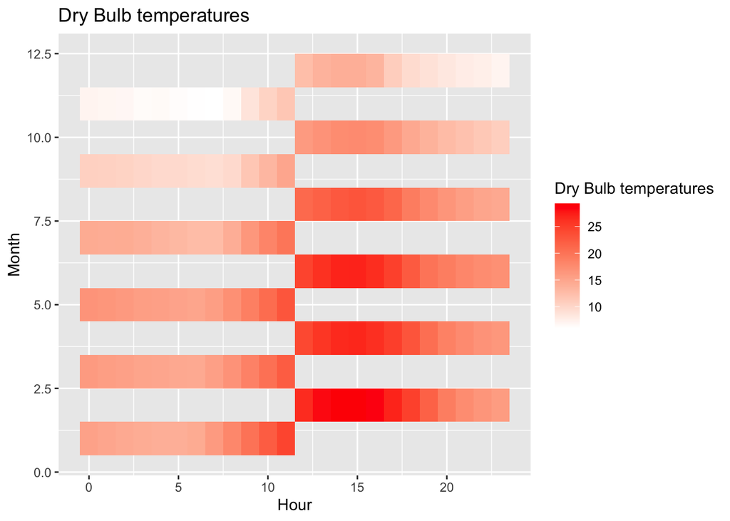

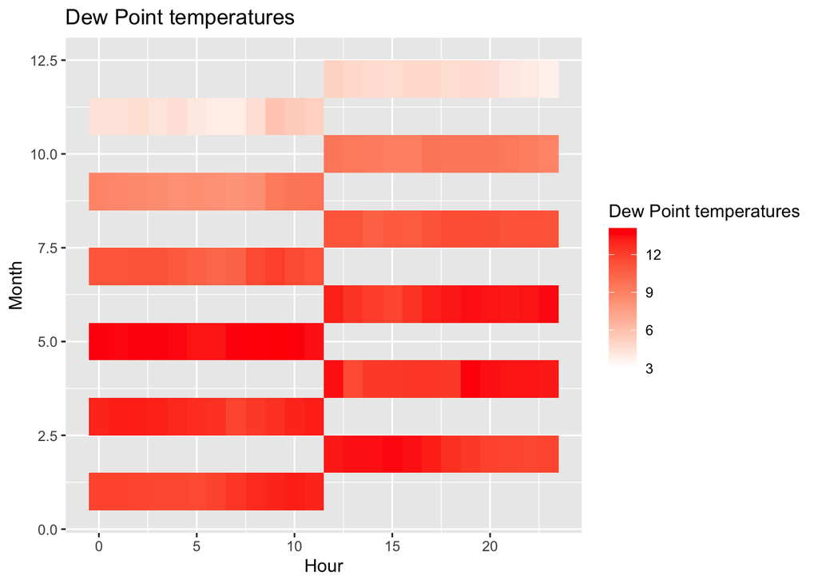

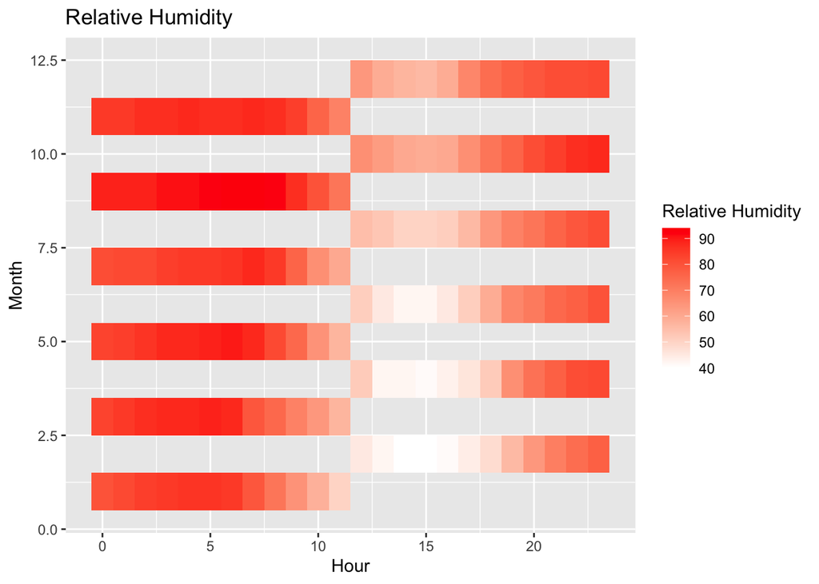

[figure not shown]

[figure not shown]

```r
#Plot
plot_hourly_df(sf_hour_combined_df)
```

## Marin County AP Gnoss.Field

### .wea file

```r
# .wea file
marin_path_wea <- "USA_CA_Marin.County.AP-Gnoss.Field.720406_TMYx.2007-2021/USA_CA_Marin.County.AP-Gnoss.Field.720406_TMYx.2007-2021.wea"
wea_data_marin <- read_wea(marin_path_wea)
head(wea_data_marin)
```

```
##   Month Day Hour Global_Horizontal_Irradiance Direct_Normal_Irradiance
## 1     1   1    1                            0                        0
## 2     1   1    2                            0                        0
## 3     1   1    3                            0                        0
## 4     1   1    4                            0                        0
## 5     1   1    5                            0                        0
## 6     1   1    6                            0                        0
```

### .pvsyst file

```r
marin_path_pvsyst <- "USA_CA_Marin.County.AP-Gnoss.Field.720406_TMYx.2007-2021/USA_CA_Marin.County.AP-Gnoss.Field.720406_TMYx.2007-2021.pvsyst"
marin_pvsyst_data <- read_pvsyst(marin_path_pvsyst)
head(marin_pvsyst_data)
```

```
##   Year Month Day Hour Minute GHI DHI DNI Tamb WindVel WindDir
## 1 2059     1   1    1     30   0   0   0    7       0     316
## 2 2059     1   1    2     30   0   0   0    5       2     170
## 3 2059     1   1    3     30   0   0   0    4       0     349
## 4 2059     1   1    4     30   0   0   0    5       2     190
## 5 2059     1   1    5     30   0   0   0    2       0      80
## 6 2059     1   1    6     30   0   0   0    2       0      98
```

### .stat file

```r
marin_statlines <- read_lines("USA_CA_Marin.County.AP-Gnoss.Field.720406_TMYx.2007-2021/USA_CA_Marin.County.AP-Gnoss.Field.720406_TMYx.2007-2021.stat", locale = locale(encoding = "ISO-8859-1"))
```

#### Monthly Statistics for Dry Bulb temperatures

```r
marin_stat_data_month_dry_bulb_temp <- read_stat("Monthly Statistics for Dry Bulb temperatures",marin_statlines)
marin_stat_data_month_dry_bulb_temp_t <- transpose_dataframe(marin_stat_data_month_dry_bulb_temp)
marin_stat_data_month_dry_bulb_temp_t <- my_convert_to_time(marin_stat_data_month_dry_bulb_temp_t)
marin_stat_data_month_dry_bulb_temp_t <- df_to_numeric(marin_stat_data_month_dry_bulb_temp_t)
head(marin_stat_data_month_dry_bulb_temp_t)
```

```
##     Maximum             Day:Hour Minimum             Day:Hour Daily Avg
## Jan       28 2023-01-18 14:00:00     -2.0 2023-01-21 08:00:00       9.5
## Feb       25 2023-02-22 15:00:00     -2.0 2023-02-27 05:00:00       9.9
## Mar       26 2023-03-18 16:00:00      3.0 2023-03-04 06:00:00      11.4
## Apr       31 2023-04-30 14:00:00      5.0 2023-04-03 07:00:00      14.1
## May       33 2023-05-02 15:00:00      6.0 2023-05-14 06:00:00      16.2
## Jun       37 2023-06-04 15:00:00      7.8 2023-06-01 03:00:00      18.3
##     Daily Range DayTime Max DayTime Min DayTime Avg NightTime Max NightTime Min
## Jan        11.7          28          -2        11.3            19          -1.0
## Feb        12.3          25          -2        11.8            20          -2.0
## Mar        11.0          26           3        13.1            22           3.0
## Apr        13.0          31           5        17.0            26           5.0
## May        14.9          33           8        19.9            25           6.0
## Jun        17.2          37          10        22.4            30           7.8
##     NightTime Avg
## Jan           7.6
## Feb           8.0
## Mar           9.7
## Apr          11.2
## May          12.6
## Jun          14.1
```

#### Monthly Statistics for Dew Point temperatures

```r
marin_stat_data_month_dew_point_temp <- read_stat("Monthly Statistics for Dew Point temperatures",marin_statlines)
marin_stat_data_month_dew_point_temp_t <- transpose_dataframe(marin_stat_data_month_dew_point_temp)
marin_stat_data_month_dew_point_temp_t <- my_convert_to_time(marin_stat_data_month_dew_point_temp_t)
marin_stat_data_month_dew_point_temp_t <- df_to_numeric(marin_stat_data_month_dew_point_temp_t)
head(marin_stat_data_month_dew_point_temp_t)
```

```
##     Maximum             Day:Hour Minimum             Day:Hour Daily Avg
## Jan     14.0 2023-01-04 11:00:00      -15 2023-01-18 15:00:00       5.6
## Feb     14.0 2023-02-10 14:00:00       -4 2023-02-15 14:00:00       5.5
## Mar     15.4 2023-03-17 19:00:00       -4 2023-03-19 02:00:00       7.3
## Apr     17.0 2023-04-08 18:00:00        1 2023-04-23 00:00:00       8.8
## May     18.0 2023-05-04 13:00:00        3 2023-05-06 02:00:00       9.4
## Jun     17.0 2023-06-01 14:00:00        1 2023-06-12 19:00:00      10.2
```

#### Average Hourly Statistics for Dry Bulb

```r
marin_stat_data_hour_dry_bulb_temp <- read_stat("Average Hourly Statistics for Dry Bulb temperatures",marin_statlines)
marin_stat_data_hour_dry_bulb_temp <- first_row_to_colnames(marin_stat_data_hour_dry_bulb_temp)
head(marin_stat_data_hour_dry_bulb_temp)
```

```
##             Jan Feb Mar  Apr  May  Jun  Jul  Aug  Sep  Oct Nov Dec
##  0:01- 1:00 7.1 7.0 9.4 10.1 11.5 12.6 12.6 12.9 12.2 12.3 8.2 5.9
##  1:01- 2:00 7.0 6.6 9.1  9.9 11.3 12.0 12.3 12.8 11.8 11.7 7.4 5.6
##  2:01- 3:00 6.7 6.4 8.5  9.6 11.1 11.4 12.2 12.9 11.8 11.2 6.9 5.4
##  3:01- 4:00 6.5 5.9 7.9  9.1 11.1 11.3 11.9 12.6 11.5 11.3 7.0 5.2
##  4:01- 5:00 6.2 6.0 7.8  9.2 10.7 11.2 11.6 12.5 11.5 10.9 6.6 4.9
##  5:01- 6:00 6.0 5.8 7.4  9.1 10.6 11.2 11.6 12.6 11.5 10.9 6.5 4.9
```

#### Average Hourly Statistics for Dew Point temperatures

```r
marin_stat_data_hour_dew_point_temp <- read_stat("Average Hourly Statistics for Dew Point temperatures",marin_statlines)
marin_stat_data_hour_dew_point_temp <- first_row_to_colnames(marin_stat_data_hour_dew_point_temp)
head(marin_stat_data_hour_dew_point_temp)
```

```
##             Jan Feb Mar Apr May Jun  Jul  Aug  Sep Oct Nov Dec
##  0:01- 1:00 5.3 5.6 7.2 8.3 8.6 9.6 12.3 10.8 11.1 8.4 4.7 4.1
##  1:01- 2:00 5.2 5.3 6.6 8.1 8.3 9.4 12.1 10.9 10.9 8.6 4.6 3.8
##  2:01- 3:00 5.1 4.8 7.1 7.9 8.1 9.4 11.9 11.1 11.2 8.4 4.4 3.8
##  3:01- 4:00 5.1 4.4 6.6 7.9 8.1 9.5 11.6 10.9 11.0 8.7 4.0 3.4
##  4:01- 5:00 4.8 4.3 6.7 7.8 8.0 9.3 11.4 11.0 10.9 8.6 3.8 3.4
##  5:01- 6:00 4.7 4.3 6.2 7.6 7.9 9.4 11.4 10.8 11.0 8.3 3.7 3.3
```

#### Average Hourly Relative Humidity

```r
marin_stat_data_hour_relative_humid <- read_stat("Average Hourly Relative Humidity",marin_statlines)
marin_stat_data_hour_relative_humid <- first_row_to_colnames(marin_stat_data_hour_relative_humid)
head(marin_stat_data_hour_relative_humid)
```

```
##             Jan Feb Mar Apr May Jun Jul Aug Sep Oct Nov Dec
##  0:01- 1:00  91  92  88  89  83  83  98  88  94  82  83  89
##  1:01- 2:00  91  92  87  89  83  84  98  89  95  84  85  89
##  2:01- 3:00  92  91  91  90  83  87  98  89  96  85  87  90
##  3:01- 4:00  93  91  92  92  83  89  98  90  97  85  86  90
##  4:01- 5:00  93  91  93  91  84  89  99  91  97  87  87  91
##  5:01- 6:00  94  91  93  91  84  89  99  89  97  86  87  90
```

#### Monthly Wind Direction

```r
marin_stat_data_month_wind_direction <- read_stat("Monthly Wind Direction",marin_statlines)
marin_stat_data_month_wind_direction_t <- transpose_dataframe(marin_stat_data_month_wind_direction)
marin_stat_data_month_wind_direction_t <- df_to_numeric(marin_stat_data_month_wind_direction_t)
head(marin_stat_data_month_wind_direction_t)
```

```
##     N (0)       ENE (22.5)  NE (45)     ENE (67.5)  E (90)      ESE (112.5)
## Jan          11           5           5           3           2           9
## Feb           7           3           4           3           2           3
## Mar          12           4           3           2           3           2
## Apr          13           3           4           3           2           3
## May          10           2           0           1           2           2
## Jun          14           6           1           2           3           4
##     SE (135)    SSE (157.5) S (180)     SSW (202.5) SW (225)    WSW (247.5)
## Jan           8           6           9           6           4           4
## Feb           3           4          10           8           4           6
## Mar           5           4           6           5           6           7
## Apr           4           2           5           3           5          11
## May           1           1           2           6          13          14
## Jun           5           2           5           4           9          13
##     W (270)     WNW (292.5) NW (315)    NNW (337.5)
## Jan           5           6           8           8
## Feb          10           9          13          11
## Mar          12          10           9          10
## Apr          14          11          10           9
## May          19          10           7          10
## Jun          15           5           4           9
```

#### Average Hourly Statistics for Direct Normal Solar Radiation

```r
marin_stat_data_hour_dircect_NSR <- read_stat("Average Hourly Statistics for Direct Normal Solar Radiation",marin_statlines)
marin_stat_data_hour_dircect_NSR <- first_row_to_colnames(marin_stat_data_hour_dircect_NSR)
head(marin_stat_data_hour_dircect_NSR)
```

```
##             Jan Feb Mar Apr   May Jun Jul Aug Sep Oct Nov Dec
##  0:01- 1:00   0   0   0   0     0   0   0   0   0   0   0   0
##  1:01- 2:00   0   0   0   0     0   0   0   0   0   0   0   0
##  2:01- 3:00   0   0   0   0     0   0   0   0   0   0   0   0
##  3:01- 4:00   0   0   0   0     0   0   0   0   0   0   0   0
##  4:01- 5:00   0   0   0   0     0   0   0   0   0   0   0   0
##  5:01- 6:00   0   0   0 121   310 376 269 126  45   0   0   0
```

#### Monthly Statistics for Wind Speed

```r
marin_stat_data_month_wind_speed <- read_stat("Monthly Statistics for Wind Speed",marin_statlines)
marin_stat_data_month_wind_speed_t <- transpose_dataframe(marin_stat_data_month_wind_speed)
marin_stat_data_month_wind_speed_t <- my_convert_to_time(marin_stat_data_month_wind_speed_t)
marin_stat_data_month_wind_speed_t <- df_to_numeric(marin_stat_data_month_wind_speed_t)
head(marin_stat_data_month_wind_speed_t)
```

```
##     Maximum            Day:Hour  Minimum            Day:Hour  Daily Avg
## Jan     12.4 2023-01-18 23:00:00        0 2023-01-01 01:00:00       1.9
## Feb     10.8 2023-02-13 06:00:00        0 2023-02-01 09:00:00       2.3
## Mar      9.3 2023-03-08 15:00:00        0 2023-03-01 01:00:00       2.4
## Apr     10.8 2023-04-22 19:00:00        0 2023-04-01 07:00:00       2.4
## May     11.3 2023-05-12 18:00:00        0 2023-05-01 01:00:00       3.0
## Jun     11.8 2023-06-16 14:00:00        0 2023-06-01 08:00:00       2.6
```

```r
marin_stat_data_hour_wind_speed <- read_stat("Average Hourly Relative Humidity",marin_statlines)
marin_stat_data_hour_wind_speed <- first_row_to_colnames(marin_stat_data_hour_wind_speed)
head(marin_stat_data_hour_wind_speed)
```

```
##             Jan Feb Mar Apr May Jun Jul Aug Sep Oct Nov Dec
##  0:01- 1:00  91  92  88  89  83  83  98  88  94  82  83  89
##  1:01- 2:00  91  92  87  89  83  84  98  89  95  84  85  89
##  2:01- 3:00  92  91  91  90  83  87  98  89  96  85  87  90
##  3:01- 4:00  93  91  92  92  83  89  98  90  97  85  86  90
##  4:01- 5:00  93  91  93  91  84  89  99  91  97  87  87  91
##  5:01- 6:00  94  91  93  91  84  89  99  89  97  86  87  90
```